# Normalization strategy comparison for Data-driven analysis of isobarically labeled proteomic data.

Joris Van Houtven, Piotr Prostko

January 13, 2021,22:13

```r
library(ggplot2)
library(stringi)
library(gridExtra)
library(dendextend)
library(kableExtra)
library(psych)
library(limma)
library(tidyverse)
library(preprocessCore)
library(CONSTANd)  # install from source: https://github.com/PDiracDelta/CONSTANd/
library(NOMAD)  # devtools::install_github("carlmurie/NOMAD")
source('other_functions.R')
source('plotting_functions.R')
```

```r
# set load_outputdata=TRUE if you want to skip long computations (normalization and DEA) and just load the previously saved data sets
load_outputdata=TRUE
data.list <- readRDS('input_data.rds')
dat.l <- data.list$dat.l # data in long format
# which proteins were spiked in?
spiked.proteins <- dat.l %>% distinct(Protein) %>% filter(stri_detect(Protein, fixed='ups')) %>% pull %>% as.character
#TEMP -remove!
# tmp=dat.l %>% distinct(Protein) %>% pull %>% as.character
# dat.l <- dat.l %>% filter(Protein %in% c(tmp[sample(1:length(tmp), size=20)], spiked.proteins))
```

```r
# specify # of varying component variants and their names
variant.names <- c('median_sweeping', 'CONSTANd', 'NOMAD', 'quantile1')
n.comp.variants <- length(variant.names)
scale.vec <- 'log'
# pick reference condition for making plots / doing DEA
referenceCondition <- '0.5'
# specify colours corresponding to biological conditions
condition.color <- tribble(
  ~Condition, ~Color,
  "0.125", 'black',
  "0.5", 'blue',
  "0.667", 'green',
  "1", 'red' )
# create data frame with sample info (distinct Run,Channel, Sample, Condition, Color)
sample.info <- get_sample_info(dat.l, condition.color)
channelNames <- remove_factors(unique(sample.info$Channel))
```

# 1 Unit component: log2 transformation of reporter ion intensities

```r
dat.unit.l <- dat.l %>% mutate(response=log2(intensity)) %>% select(-intensity)
```

# 2 Normalization component

```r
# switch to wide format
dat.unit.w <- pivot_wider(data = dat.unit.l, id_cols=-one_of(c('Condition', 'BioReplicate')), names_from=Channel, values_from=response)
```

```r
dat.norm.w <- emptyList(variant.names)
```

## 2.1 median sweeping (1)

```r
if (!load_outputdata){
# subtract the spectrum median log2intensity from the observed log2intensities
dat.norm.w$median_sweeping <- dat.unit.w
dat.norm.w$median_sweeping[,channelNames] <- median_sweep(dat.norm.w$median_sweeping[,channelNames], 1, '-')
}
```

## 2.2 CONSTANd

```r
if (!load_outputdata){
# dat.unit.l entries are in long format so all have same colnames and no channelNames
x.split <- split(dat.unit.w, dat.unit.w$Run)  # apply CONSTANd to each Run separately
x.split.norm  <- lapply(x.split, function(y) {
  y[,channelNames] <- CONSTANd(y[,channelNames])$normalized_data
  return(y)
})
dat.norm.w$CONSTANd <- bind_rows(x.split.norm)
}
```

## 2.3 NOMAD

We apply NOMAD on the PSM level instead of the peptide level.

```r
if (!load_outputdata){
# doRobust=F: use means, like CONSTANd; doLog=F: values are already transformed.
dat.nomadnorm <- nomadNormalization(dat.unit.l$response, dat.unit.l %>% rename(iTRAQ=Channel) %>% as.data.frame, doRobust = FALSE, doiTRAQCorrection = FALSE, doLog = FALSE)
dat.nomadnorm$x$response <- dat.nomadnorm$y
dat.norm.w$NOMAD <- pivot_wider(data = dat.nomadnorm$x, id_cols=-one_of(c('Condition', 'BioReplicate')), names_from=iTRAQ, values_from=response)
}
```

## 2.4 Quantile (1)

We apply quantile normalization to each Run separately, and then re-scale the observations so that the mean observation within in each run is set equal to the mean observation across all runs.

```r
if (!load_outputdata){
grand_average <- mean(as.matrix(dat.unit.w[,channelNames]))
x.split <- split(dat.unit.w, dat.unit.w$Run)
x.split.norm <- lapply(x.split, function(y) {
  # apply normalizeQuantiles to each Run separately
  y[,channelNames] <- normalize.quantiles(as.matrix(y[,channelNames]))
  # make averages of all runs equal.
  y[,channelNames] <- y[,channelNames] / mean(colMeans(y[,channelNames])) * grand_average
  return(y)
})
dat.norm.w$quantile1 <- bind_rows(x.split.norm)
}
```

# 3 Summarization component: Median summarization

Summarize quantification values from PSM to peptide (first step) to protein (second step).

```r
if (!load_outputdata){
# normalized data
dat.norm.summ.w <- lapply(dat.norm.w, function(x){
  y <- x %>% group_by(Run, Protein, Peptide) %>% summarise_at(.vars = channelNames, .funs = median, na.rm=T) %>% summarise_at(.vars = channelNames, .funs = median, na.rm=T) %>% ungroup()
  return(y)})
}
```

Let’s also summarize the non-normalized data for comparison in the next section.

```r
if (!load_outputdata){
# non-normalized data
# group by (run,)protein,peptide then summarize twice (once on each level)
# add select() statement because summarise_at is going bananas over character columns
dat.nonnorm.summ.w <- dat.unit.w %>% group_by(Run, Protein, Peptide) %>% select(Run, Protein, Peptide, channelNames) %>% summarise_at(.vars = channelNames, .funs = median) %>% select(Run, Protein, channelNames) %>% summarise_at(.vars = channelNames, .funs = median) %>% ungroup()
}
```

```r
if (!load_outputdata){
# make data completely wide (also across runs)
## normalized data
dat.norm.summ.w2 <- lapply(dat.norm.summ.w, function(x) {
  return(x %>% pivot_wider(names_from = Run, values_from = all_of(channelNames), names_glue = "{Run}:{.value}"))
})
}
```

# 4 Normalization component (2)

## 4.1 Median sweeping (2)

```r
if (!load_outputdata){
# median sweeping: in each channel, subtract median computed across all proteins within the channel, separately for each MS run.
tmp <- dat.norm.summ.w2$median_sweeping %>% select(-Protein)
dat.norm.summ.w2$median_sweeping[, colnames(dat.norm.summ.w2$median_sweeping)!='Protein'] <- median_sweep(tmp, 2, '-')
}
```

## 4.2 Quantile (2)

```r
if (!load_outputdata){
# apply normalizeQuantiles again, now to the data from all runs simultaneously
dat.norm.summ.w2$quantile1[,sample.info$Sample] <- normalize.quantiles(as.matrix(dat.norm.summ.w2$quantile1[,sample.info$Sample]))
}
```

## 4.3 Quantile norm of protein-level data by condition

```r
if (!load_outputdata){
dat.nonnorm.summ.l <- to_long_format(dat.nonnorm.summ.w, sample.info)
x.split <- split(dat.nonnorm.summ.l, dat.nonnorm.summ.l$Condition)
x.split.norm <- lapply(x.split, function(x){
  tmp.wide <- pivot_wider(data=x, id_cols='Protein', names_from=Sample, values_from=response)
  tmp.wide[, colnames(tmp.wide)!='Protein'] <- normalize.quantiles(as.matrix(tmp.wide %>% select(-Protein)))
  tmp <- pivot_longer(tmp.wide, cols=-one_of('Protein'), names_to='Sample', values_to='response') %>% drop_na() %>% inner_join(sample.info[,c('Sample', 'Run', 'Channel', 'Condition')], by='Sample')
  return(tmp)
})
x <- bind_rows(x.split.norm)
dat.norm.summ.w$quantile2 <- pivot_wider(data = x, id_cols=-one_of('Condition', 'Sample'), names_from=Channel, values_from=response)
dat.norm.summ.w2$quantile2 <- dat.norm.summ.w$quantile2 %>% pivot_wider(names_from = Run, values_from = all_of(channelNames), names_glue = "{Run}:{.value}")
}
variant.names <- c('median_sweeping', 'CONSTANd', 'NOMAD', 'quantile1', 'quantile2')
n.comp.variants <- length(variant.names)
```

# 5 QC plots

```r
if (!load_outputdata){
# make data completely wide (also across runs)
## non-normalized data
dat.nonnorm.summ.w2 <- dat.nonnorm.summ.w %>% pivot_wider(names_from = Run, values_from = all_of(channelNames), names_glue = "{Run}:{.value}")
}
```

## 5.1 Boxplots

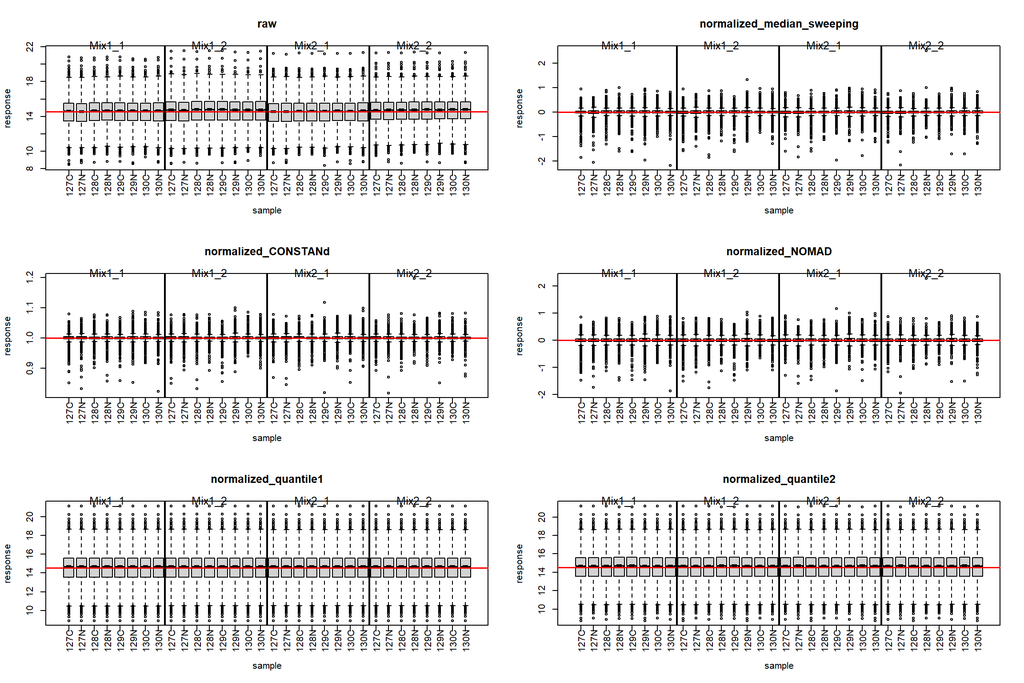

```r
# use (half-)wide format
par(mfrow=c(3,2))
boxplot_w(dat.nonnorm.summ.w,sample.info, 'raw')
for (i in 1:n.comp.variants){
  boxplot_w(dat.norm.summ.w[[variant.names[i]]], sample.info, paste('normalized', variant.names[i], sep='_'))}
```

## 5.2 MA plots

MA plots of two single samples taken from condition 1 and condition 0.125, measured in different MS runs (samples *Mixture2_1:127C* and *Mixture1_2:129N*, respectively).

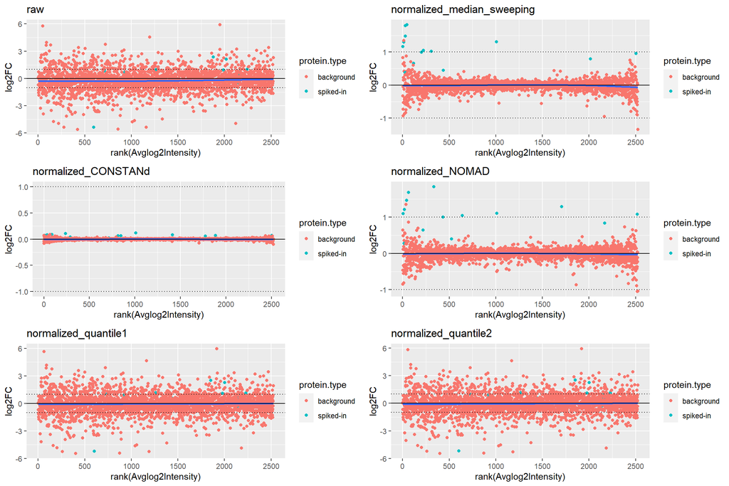

```r
# use wide2 format
p <- vector('list', n.comp.variants+1)
p[[1]] <- maplot_ils(dat.nonnorm.summ.w2, 'Mixture2_1:127C', 'Mixture1_2:129N', scale.vec, 'raw', spiked.proteins)
for (i in 1: n.comp.variants){
 p[[i+1]]<- maplot_ils(dat.norm.summ.w2[[variant.names[i]]], 'Mixture2_1:127C', 'Mixture1_2:129N', scale.vec, paste('normalized', variant.names[i], sep='_'), spiked.proteins)}
grid.arrange(grobs = p, ncol=2, nrow=3)
```

MA plots of all samples from condition `1` and condition `0.125` (quantification values averaged within condition).

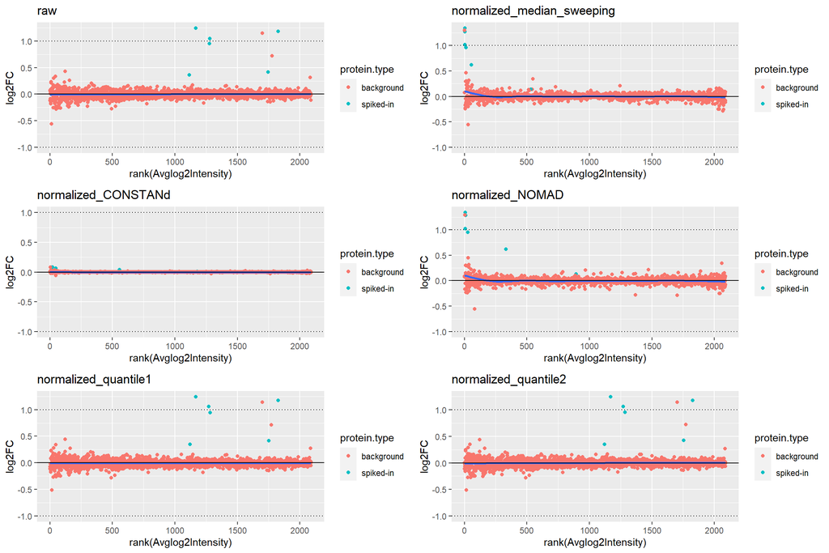

```r
channels.num <- sample.info %>% filter(Condition=='1') %>% select(Sample) %>% pull
channels.denom <- sample.info %>% filter(Condition=='0.125') %>% select(Sample) %>% pull
p <- vector('list', n.comp.variants+1)
p[[1]] <- maplot_ils(dat.nonnorm.summ.w2, channels.num, channels.denom, scale.vec, 'raw', spiked.proteins)
for (i in 1: n.comp.variants){
 p[[i+1]]<- maplot_ils(dat.norm.summ.w2[[variant.names[i]]], channels.num, channels.denom, scale.vec, paste('normalized', variant.names[i], sep='_'), spiked.proteins)}
grid.arrange(grobs = p, ncol=2)
```

## 5.3 PCA plots

### 5.3.1 Using all proteins

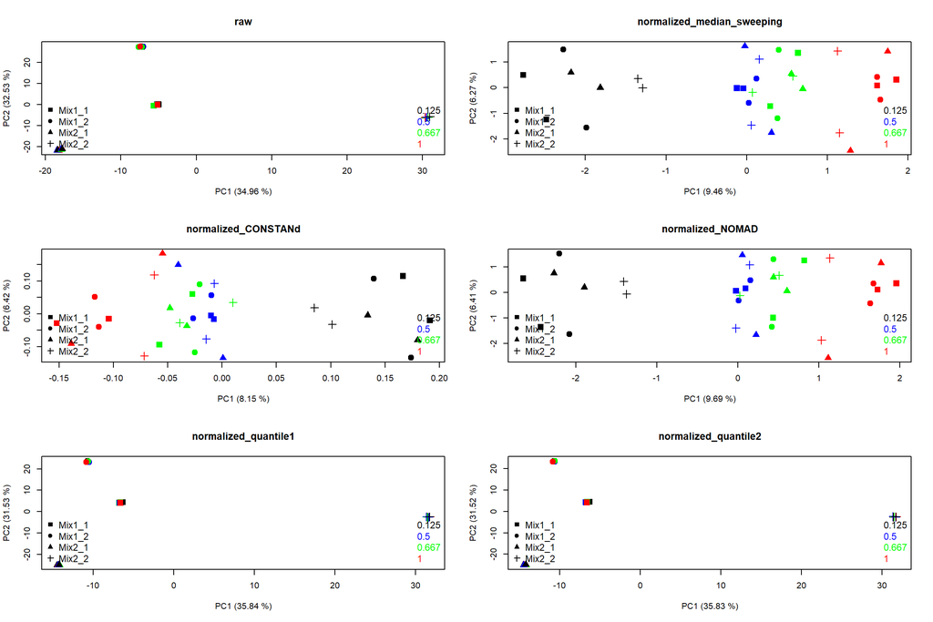

```r
par(mfrow=c(3,2))
pcaplot_ils(dat.nonnorm.summ.w2 %>% select(-'Protein'), info=sample.info, 'raw')
for (i in 1:n.comp.variants){
pcaplot_ils(dat.norm.summ.w2[[variant.names[i]]] %>% select(-'Protein'), info=sample.info, paste('normalized', variant.names[i], sep='_'))}
```

### 5.3.2 Using spiked proteins only

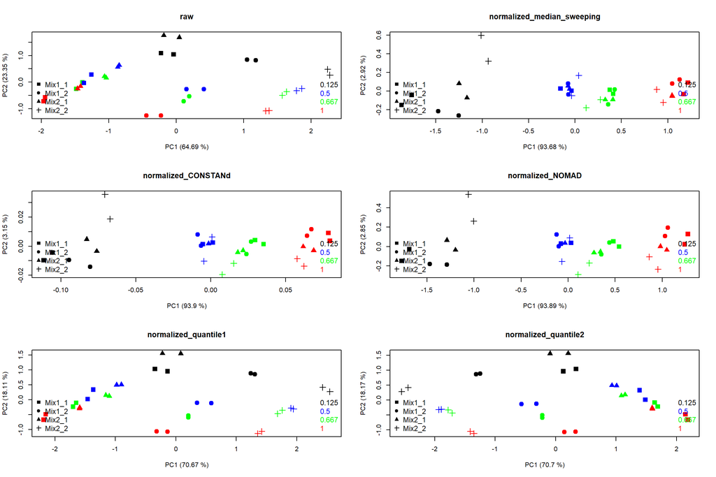

```r
par(mfrow=c(3,2))
pcaplot_ils(dat.nonnorm.summ.w2 %>% filter(Protein %in% spiked.proteins) %>% select(-'Protein'), info=sample.info, 'raw')
for (i in 1:n.comp.variants){
  pcaplot_ils(dat.norm.summ.w2[[variant.names[i]]] %>% filter(Protein %in% spiked.proteins) %>% select(-'Protein'), info=sample.info, paste('normalized', variant.names[i], sep='_'))}
```

## 5.4 HC (hierarchical clustering) plots

### 5.4.1 Using all proteins

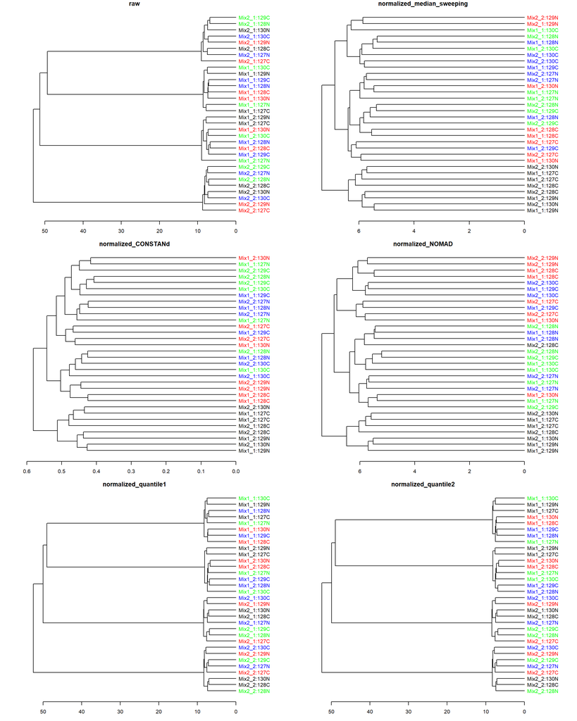

```r
par(mfrow=c(3,2))
dendrogram_ils(dat.nonnorm.summ.w2 %>% select(-Protein), info=sample.info, 'raw')
for (i in 1:n.comp.variants){
  dendrogram_ils(dat.norm.summ.w2[[variant.names[i]]] %>% select(-Protein), info=sample.info, paste('normalized', variant.names[i], sep='_'))}
```

## 5.5 Run effect p-value plot

Below the histograms of p-values from the linear model explaining the response variable with Run as a covariate.

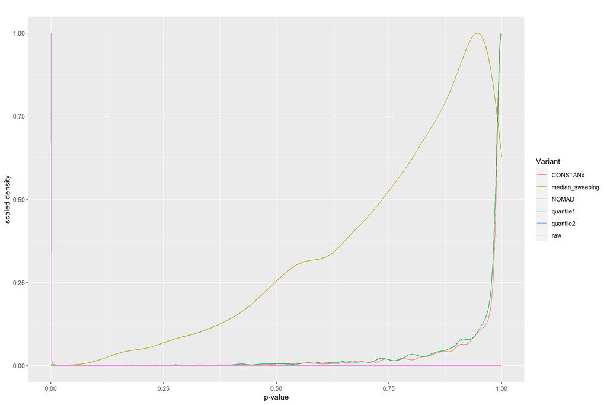

```r
dat <- vector('list',length(dat.norm.summ.l)+1)
dat[[1]] <- dat.nonnorm.summ.l; dat[2:length(dat)] <- dat.norm.summ.l[1:length(dat.norm.summ.l)]
names(dat) <- c('raw', names(dat.norm.summ.l))
run_effect_plot(dat)
```

# 6 DEA component: Moderated t-test

TODO: - Also try to log-transform the intensity case, to see if there are large differences in the t-test results. - done. remove this code? NOTE: - actually, lmFit (used in moderated_ttest) was built for log2-transformed data. However, supplying untransformed intensities can also work. This just means that the effects in the linear model are also additive on the untransformed scale, whereas for log-transformed data they are multiplicative on the untransformed scale. Also, there may be a bias which occurs from biased estimates of the population means in the t-tests, as mean(X) is not equal to exp(mean(log(X))).

```r
if (!load_outputdata){
design.matrix <- get_design_matrix(referenceCondition, sample.info)
dat.dea <- emptyList(names(dat.norm.summ.w2))
for (i in 1:n.comp.variants) {
  this_scale <- scale.vec
  d <- column_to_rownames(as.data.frame(dat.norm.summ.w2[[variant.names[i]]]), 'Protein')
  dat.dea[[variant.names[i]]] <- moderated_ttest(dat=d, design.matrix, scale=this_scale)}
# also see what the unnormalized results would look like
n.comp.variants <- n.comp.variants + 1
variant.names <- c(variant.names, 'raw')
dat.dea$raw <- moderated_ttest(dat=column_to_rownames(dat.nonnorm.summ.w2, 'Protein'), design.matrix, scale='log')
}
```

# 7 Results comparison

## 7.1 Confusion matrix

```r
cm <- conf_mat(dat.dea, 'q.mod', 0.05, spiked.proteins)
print_conf_mat(cm, referenceCondition)
```

|  | 0.125 vs 0.5 contrast median_sweeping background | 0.125 vs 0.5 contrast median_sweeping spiked | 0.125 vs 0.5 contrast CONSTANd background | 0.125 vs 0.5 contrast CONSTANd spiked | 0.125 vs 0.5 contrast NOMAD background | 0.125 vs 0.5 contrast NOMAD spiked | 0.125 vs 0.5 contrast quantile1 background | 0.125 vs 0.5 contrast quantile1 spiked | 0.125 vs 0.5 contrast quantile2 background | 0.125 vs 0.5 contrast quantile2 spiked | 0.125 vs 0.5 contrast raw background | 0.125 vs 0.5 contrast raw spiked |
| --- | --- | --- | --- | --- | --- | --- | --- | --- | --- | --- | --- | --- |
| not_DE | 4061 | 4 | 4061 | 5 | 4062 | 4 | 4064 | 15 | 4064 | 15 | 4064 | 15 |
| DE | 3 | 15 | 3 | 14 | 2 | 15 | 0 | 4 | 0 | 4 | 0 | 4 |

|  | 0.125 vs 0.5 contrast median_sweeping | 0.125 vs 0.5 contrast CONSTANd | 0.125 vs 0.5 contrast NOMAD | 0.125 vs 0.5 contrast quantile1 | 0.125 vs 0.5 contrast quantile2 | 0.125 vs 0.5 contrast raw |
| --- | --- | --- | --- | --- | --- | --- |
| Accuracy | 0.998 | 0.998 | 0.999 | 0.996 | 0.996 | 0.996 |
| Sensitivity | 0.789 | 0.737 | 0.789 | 0.211 | 0.211 | 0.211 |
| Specificity | 0.999 | 0.999 | 1.000 | 1.000 | 1.000 | 1.000 |
| PPV | 0.833 | 0.824 | 0.882 | 1.000 | 1.000 | 1.000 |
| NPV | 0.999 | 0.999 | 0.999 | 0.996 | 0.996 | 0.996 |

|  | 0.667 vs 0.5 contrast median_sweeping background | 0.667 vs 0.5 contrast median_sweeping spiked | 0.667 vs 0.5 contrast CONSTANd background | 0.667 vs 0.5 contrast CONSTANd spiked | 0.667 vs 0.5 contrast NOMAD background | 0.667 vs 0.5 contrast NOMAD spiked | 0.667 vs 0.5 contrast quantile1 background | 0.667 vs 0.5 contrast quantile1 spiked | 0.667 vs 0.5 contrast quantile2 background | 0.667 vs 0.5 contrast quantile2 spiked | 0.667 vs 0.5 contrast raw background | 0.667 vs 0.5 contrast raw spiked |
| --- | --- | --- | --- | --- | --- | --- | --- | --- | --- | --- | --- | --- |
| not_DE | 4062 | 17 | 4064 | 15 | 4064 | 17 | 4064 | 19 | 4064 | 19 | 4064 | 19 |
| DE | 2 | 2 | 0 | 4 | 0 | 2 | 0 | 0 | 0 | 0 | 0 | 0 |

|  | 0.667 vs 0.5 contrast median_sweeping | 0.667 vs 0.5 contrast CONSTANd | 0.667 vs 0.5 contrast NOMAD | 0.667 vs 0.5 contrast quantile1 | 0.667 vs 0.5 contrast quantile2 | 0.667 vs 0.5 contrast raw |
| --- | --- | --- | --- | --- | --- | --- |
| Accuracy | 0.995 | 0.996 | 0.996 | 0.995 | 0.995 | 0.995 |
| Sensitivity | 0.105 | 0.211 | 0.105 | 0.000 | 0.000 | 0.000 |
| Specificity | 1.000 | 1.000 | 1.000 | 1.000 | 1.000 | 1.000 |
| PPV | 0.500 | 1.000 | 1.000 | NaN | NaN | NaN |
| NPV | 0.996 | 0.996 | 0.996 | 0.995 | 0.995 | 0.995 |

|  | 1 vs 0.5 contrast median_sweeping background | 1 vs 0.5 contrast median_sweeping spiked | 1 vs 0.5 contrast CONSTANd background | 1 vs 0.5 contrast CONSTANd spiked | 1 vs 0.5 contrast NOMAD background | 1 vs 0.5 contrast NOMAD spiked | 1 vs 0.5 contrast quantile1 background | 1 vs 0.5 contrast quantile1 spiked | 1 vs 0.5 contrast quantile2 background | 1 vs 0.5 contrast quantile2 spiked | 1 vs 0.5 contrast raw background | 1 vs 0.5 contrast raw spiked |
| --- | --- | --- | --- | --- | --- | --- | --- | --- | --- | --- | --- | --- |
| not_DE | 4060 | 5 | 4059 | 5 | 4062 | 5 | 4064 | 16 | 4064 | 17 | 4064 | 17 |
| DE | 4 | 14 | 5 | 14 | 2 | 14 | 0 | 3 | 0 | 2 | 0 | 2 |

|  | 1 vs 0.5 contrast median_sweeping | 1 vs 0.5 contrast CONSTANd | 1 vs 0.5 contrast NOMAD | 1 vs 0.5 contrast quantile1 | 1 vs 0.5 contrast quantile2 | 1 vs 0.5 contrast raw |
| --- | --- | --- | --- | --- | --- | --- |
| Accuracy | 0.998 | 0.998 | 0.998 | 0.996 | 0.996 | 0.996 |
| Sensitivity | 0.737 | 0.737 | 0.737 | 0.158 | 0.105 | 0.105 |
| Specificity | 0.999 | 0.999 | 1.000 | 1.000 | 1.000 | 1.000 |
| PPV | 0.778 | 0.737 | 0.875 | 1.000 | 1.000 | 1.000 |
| NPV | 0.999 | 0.999 | 0.999 | 0.996 | 0.996 | 0.996 |

## 7.2 Scatter plots

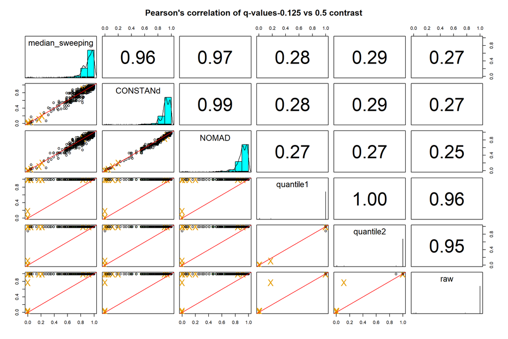

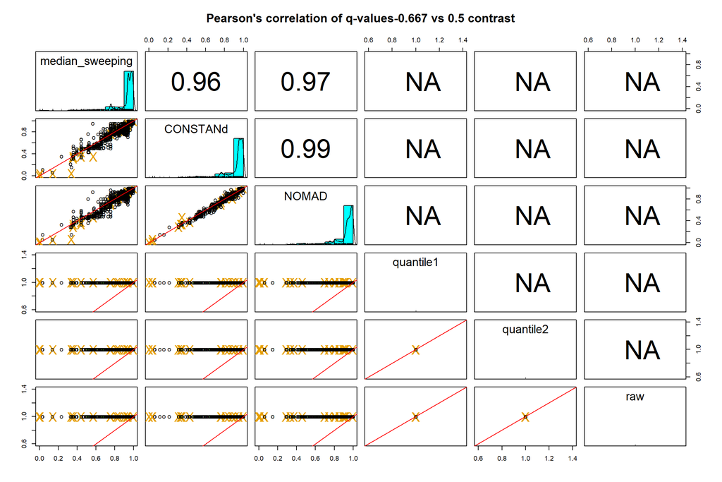

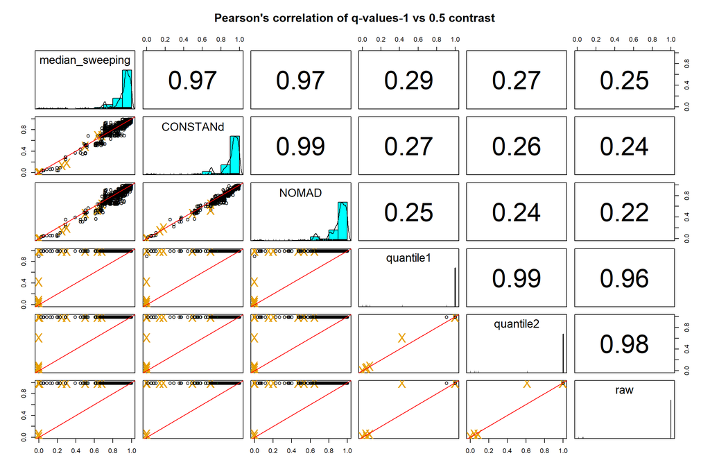

```r
# character vectors containing logFC and p-values columns
dea.cols <- colnames(dat.dea[[1]])
logFC.cols <- dea.cols[stri_detect_fixed(dea.cols, 'logFC')]
significance.cols <- dea.cols[stri_detect_fixed(dea.cols, 'q.mod')]
n.contrasts <- length(logFC.cols)

scatterplot_ils(dat.dea, significance.cols, 'q-values', spiked.proteins)
```

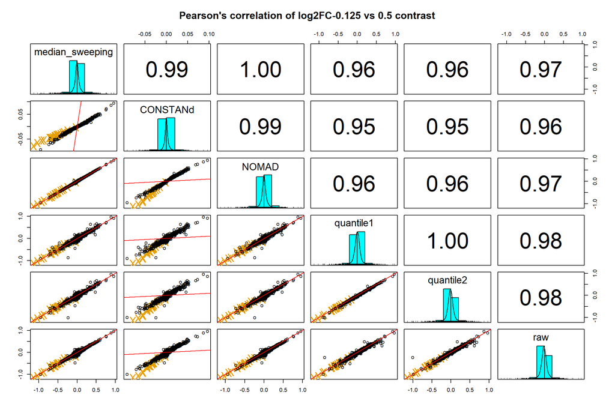

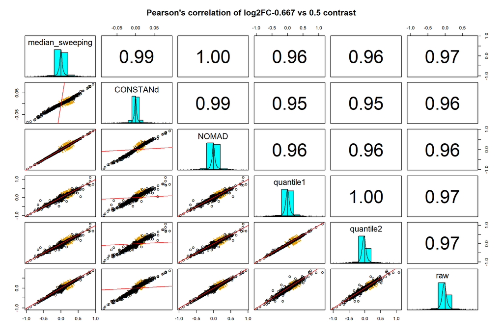

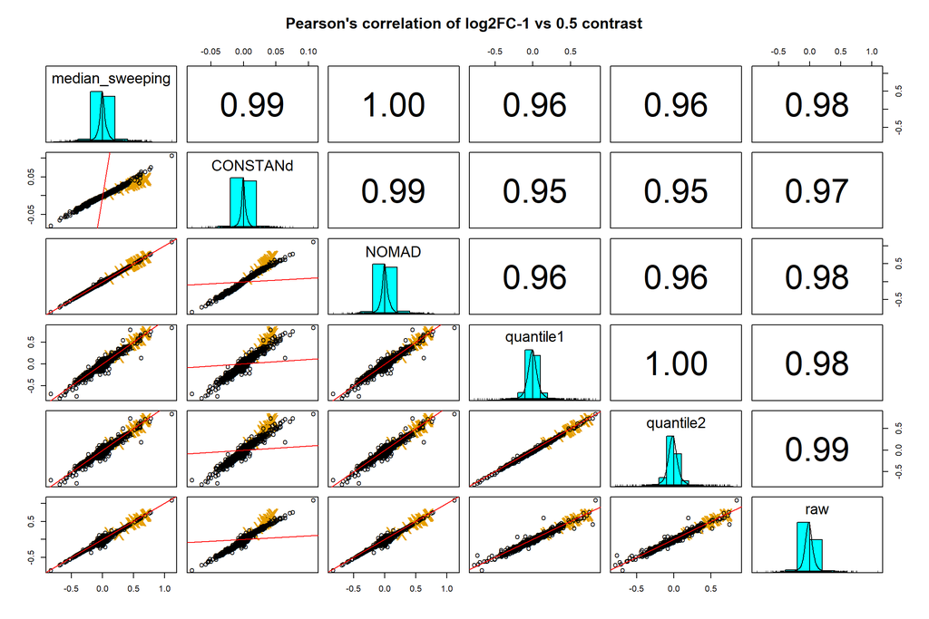

```r
scatterplot_ils(dat.dea, logFC.cols, 'log2FC', spiked.proteins)
```

## 7.3 Volcano plots

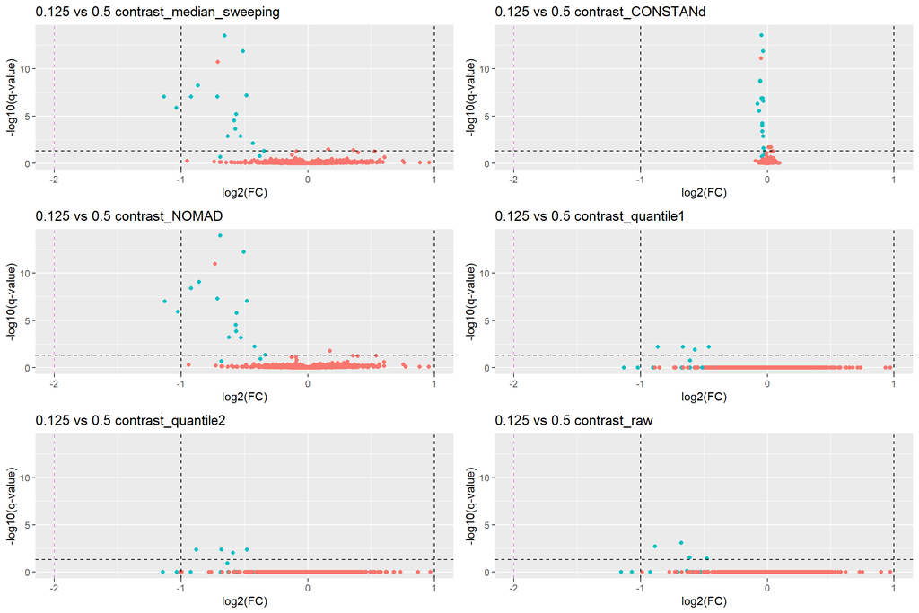

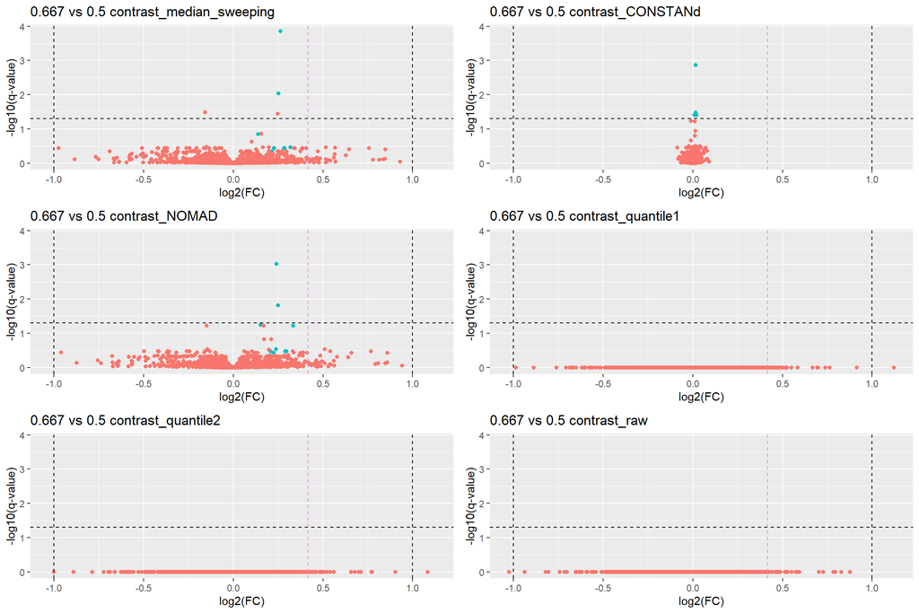

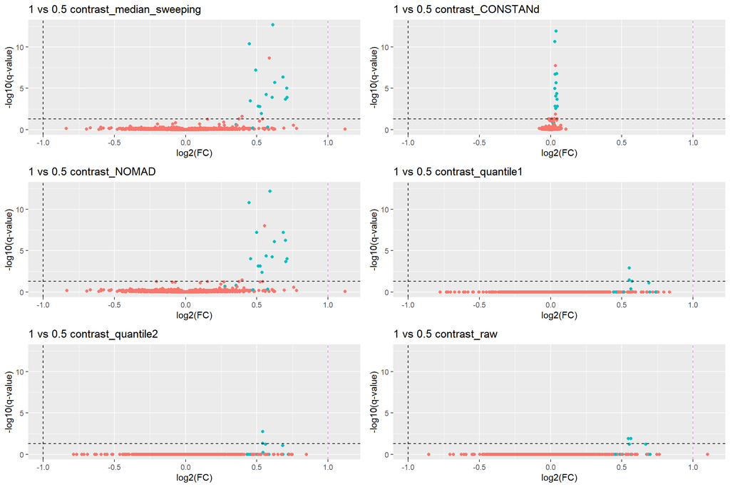

```r
for (i in 1:n.contrasts){
  volcanoplot_ils(dat.dea, i, spiked.proteins)}
```

## 7.4 Violin plots

Let’s see whether the spiked protein fold changes make sense

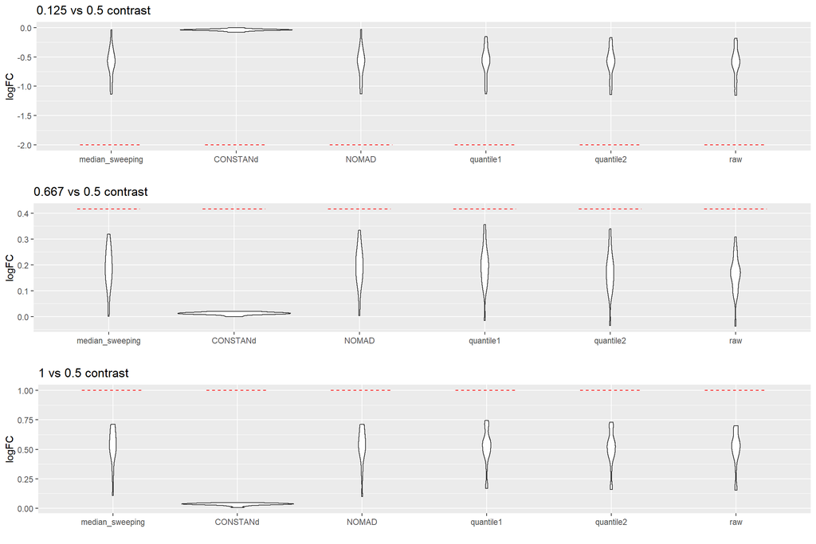

```r
# plot theoretical value (horizontal lines) and violin per variant
violinplot_ils(lapply(dat.dea, function(x) x[spiked.proteins, logFC.cols]), referenceCondition)
```

# 8 Conclusions